# Exploring Seasonality Patterns on the EuStockMarket Dataset

Danilo Zavarize

July 29, 2022

### The dataset `EuStockMarket` Contains the daily closing prices of major European stock indices: Germany DAX (Ibis), Switzerland SMI, France CAC, and UK FTSE. The data are sampled in business time, i.e., weekends and holidays are omitted.

#### **INITIAL STEPS**

```r
# Calling Packages
library(ggfortify)
library(zoo)
library(tseries)
library(astsa)
library(forecast)
library(ggplot2)
library(psych)

# Getting Data
data(EuStockMarkets)
```

#### **PART A:** For the 4 indexes, plots the ACF with lag of up to 1000 days. What differences do you see between the 4 stocks.

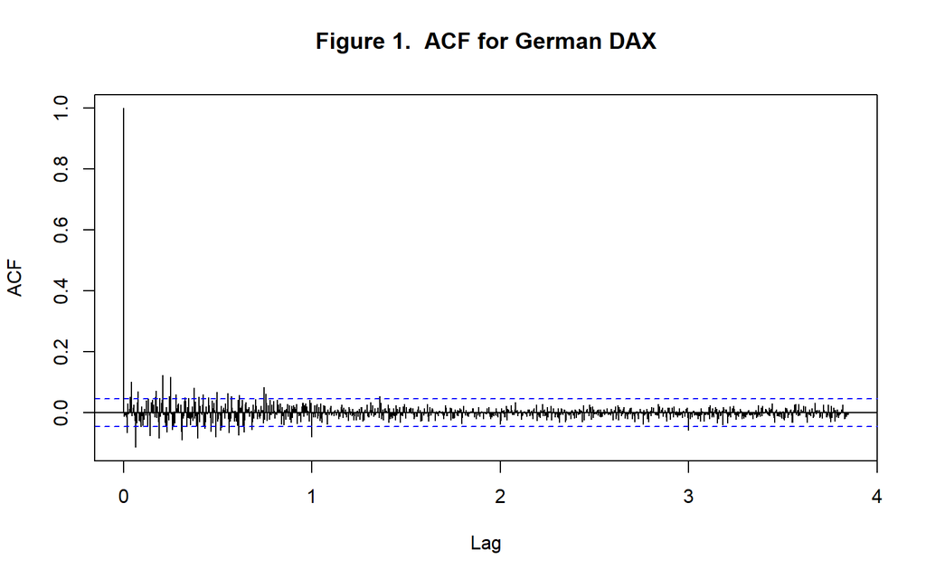

```r
# Plot - Germany DAX (Ibis)
DAX <- (EuStockMarkets[,1])
components.DAX = decompose(DAX)
x_DAX = DAX- components.DAX$seasonal
DAX_d <- diff(x_DAX, differences=1)
acf(DAX_d,lag.max = 1000,main="Figure 1.  ACF for German DAX")
```

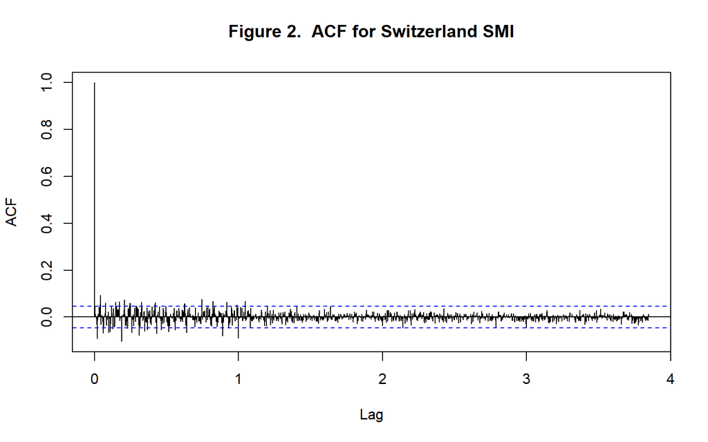

```r
# Plot - Switzerland SMI
SMI <- (EuStockMarkets[,2])
components.SMI = decompose(SMI)
x_SMI = SMI- components.SMI$seasonal
SMI_d <- diff(x_SMI, differences=1)
acf(SMI_d,lag.max = 1000,main="Figure 2.  ACF for Switzerland SMI")
```

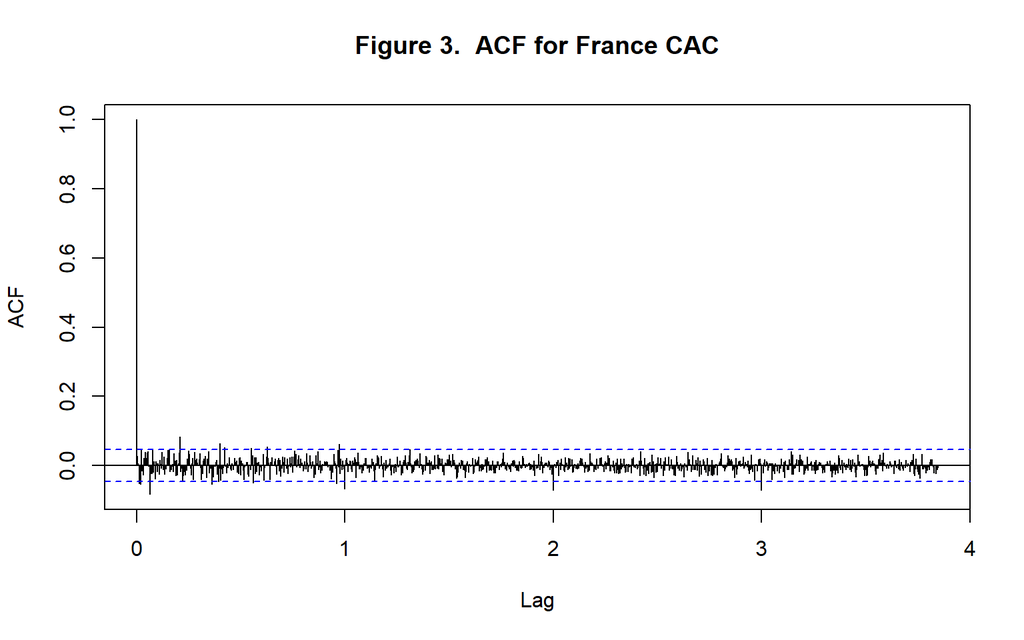

```r
# Plot - France CAC
CAC <- (EuStockMarkets[,3])
components.CAC = decompose(CAC)
x_CAC = CAC- components.CAC$seasonal
CAC_d <- diff(x_CAC, differences=1)
acf(CAC_d,lag.max = 1000,main="Figure 3.  ACF for France CAC")
```

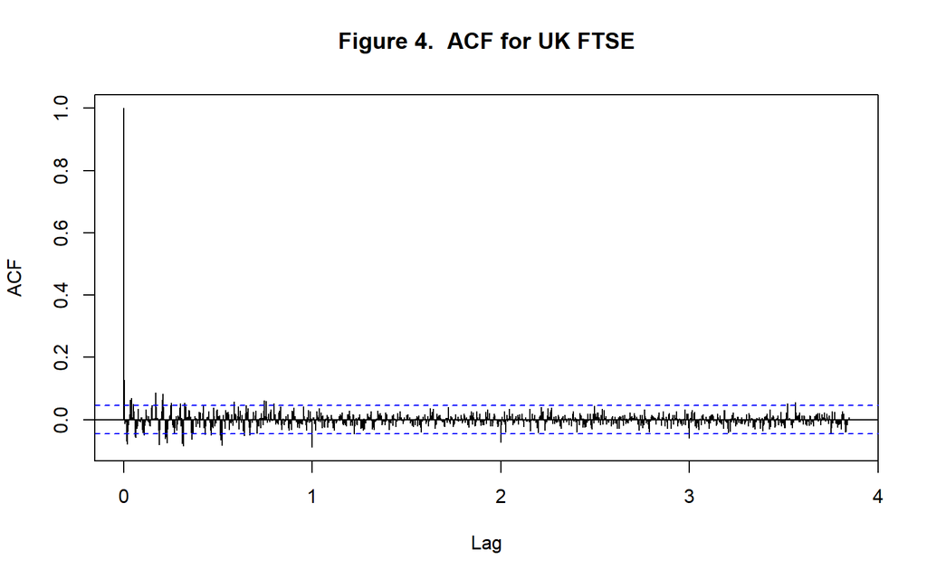

```r
# Plot - UK FTSE
FTSE <- (EuStockMarkets[,4])
components.FTSE = decompose(FTSE)
x_FTSE = FTSE- components.FTSE$seasonal
FTSE_d <- diff(x_FTSE, differences=1)
acf(FTSE_d,lag.max = 1000,main="Figure 4.  ACF for UK FTSE")
```

##### As observed from the ACF plots, each of the stocks seem to present a similar behavior in terms of autocorrelation. That is, all of the 4 graphs have a significant spike up to the first lag which is the common behavior for time series for MA(q) models. These ACF shapes also suggest a moving average process. However, practice of more than one model other MA(q) should be tested in order to check this presupposition.

#### **PART B:** Plot the time decomposition for the French CAC index. What are the differences in seasonality comparing CAC with SMI?

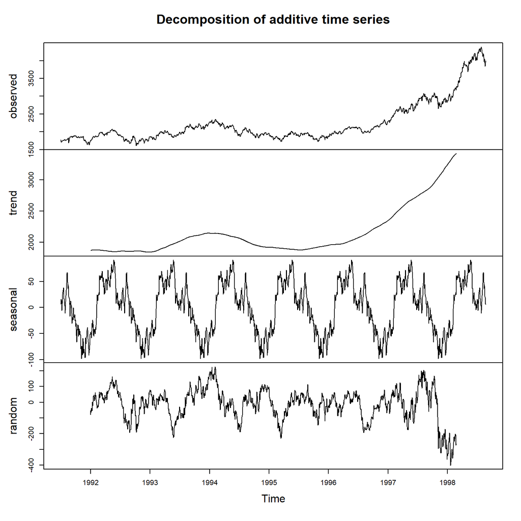

```r
# Decomposition of CAC
components.CAC = decompose(CAC)
plot(components.CAC)
```

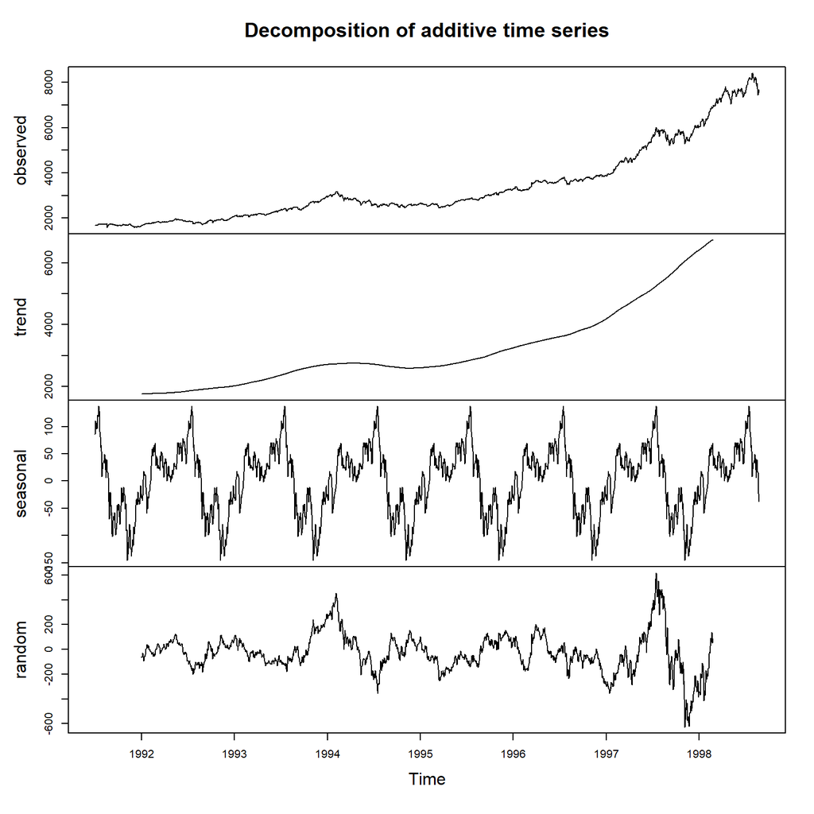

```r
# Decomposition of SMI
components.SMI = decompose(SMI)
plot(components.SMI)
```

#### **PART C:** Make a scatter plot of the seasonality values between all 4 indexes (4x4 plot). Which indexes have the highest seasonality correlation with each other?

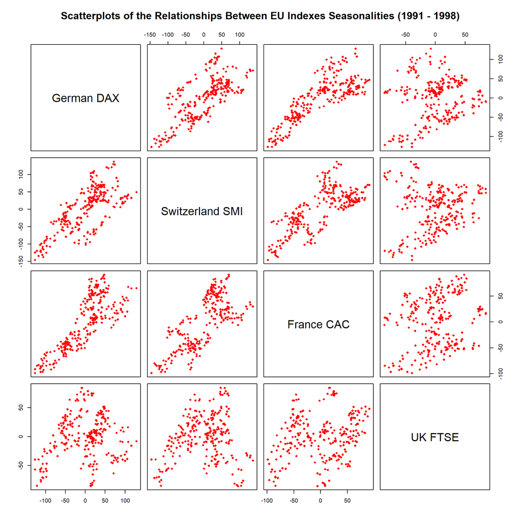

```r
# 4x4 Plot
DAX_season <- as.vector(components.DAX$seasonal)
SMI_season <- as.vector(components.SMI$seasonal)
CAC_season <- as.vector(components.CAC$seasonal)
FTSE_season <- as.vector(components.FTSE$seasonal)
season.df <- as.data.frame(cbind(DAX_season, SMI_season, CAC_season, FTSE_season))
pairs(season.df,col = "red",
      pch = 18,
      labels = c("German DAX", "Switzerland SMI", "France CAC", "UK FTSE"),
      main = "Scatterplots of the Relationships Between EU Indexes Seasonalities (1991 - 1998)")
```

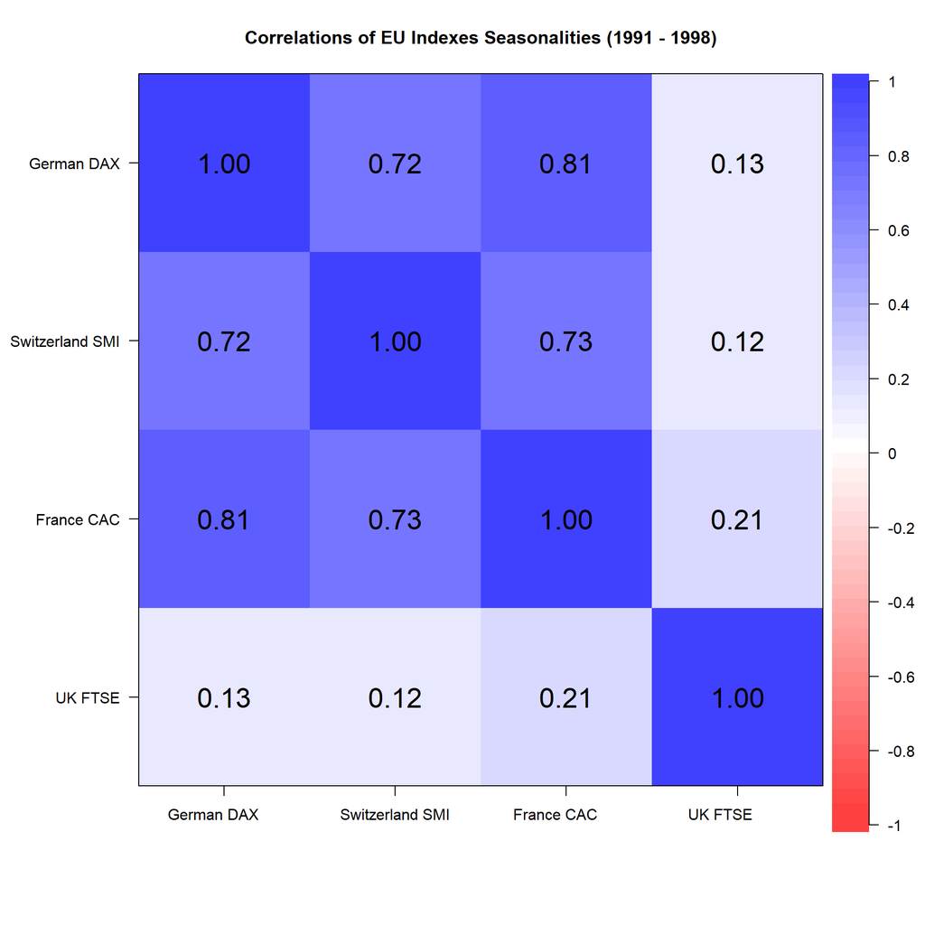

```r
# Correlations
corPlot(season.df,
        cex = 1.2,
        labels =c("German DAX", "Switzerland SMI", "France CAC", "UK FTSE"),
        main = "Correlations of EU Indexes Seasonalities (1991 - 1998)")
```